# Which smartphone characteristics significantly predict the availability of extended memory?

```python
import numpy as np
import pandas as pd
import matplotlib.pyplot as plt
import seaborn as sns
from sklearn.model_selection import train_test_split, GridSearchCV
from sklearn.preprocessing import MinMaxScaler, LabelEncoder
from sklearn.compose import ColumnTransformer
from sklearn.pipeline import Pipeline
from sklearn.metrics import confusion_matrix, accuracy_score, precision_score, recall_score, f1_score, roc_auc_score, classification_report
from sklearn.svm import SVC
```

In the logistic regression analysis, we identified a reduced model by eliminating insignificant features and applying regularization techniques. The final selected features are: price, average rating, 5G availability, processor speed, battery capacity, fast charging availability, RAM capacity, refresh rate, and primary camera front. We found these results in R part. Based on this formulation, we decided to use these features consistently in the machine learning part when modeling extended memory availability.

# SVM

[output not shown]

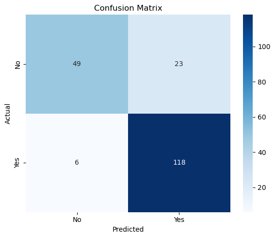

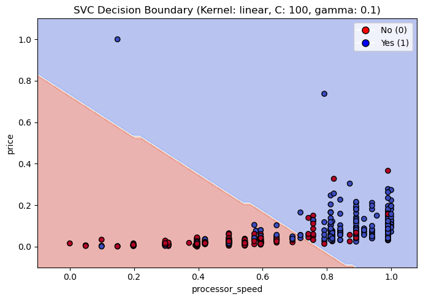

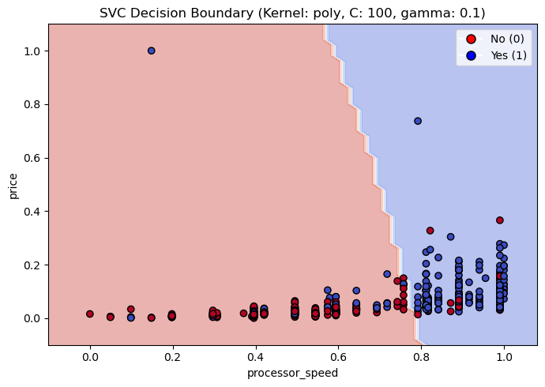

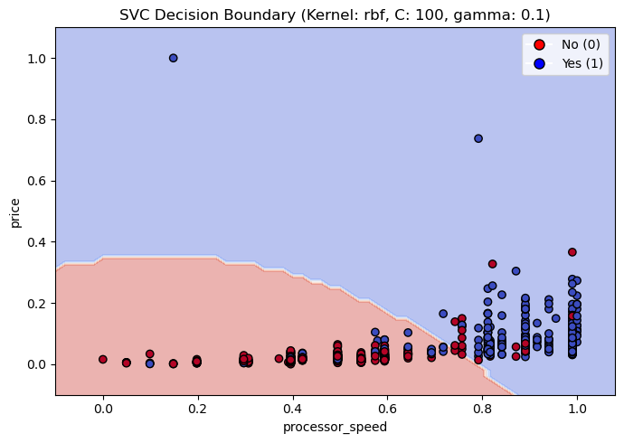

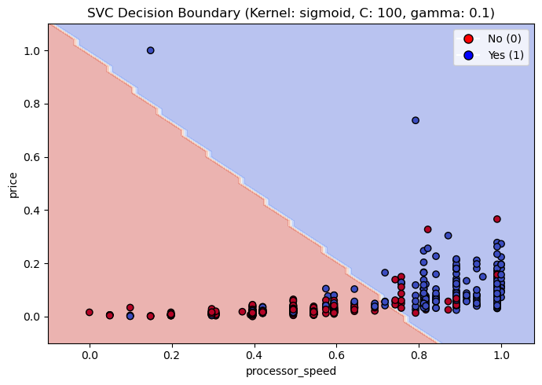

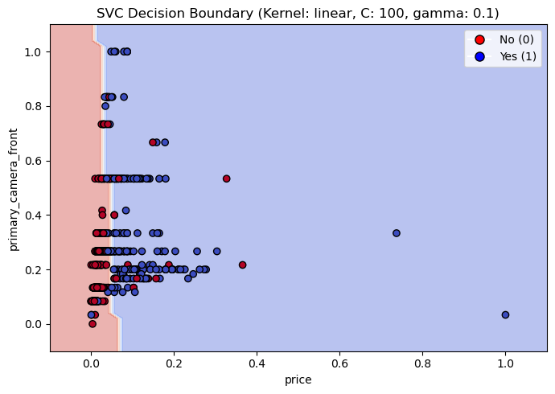

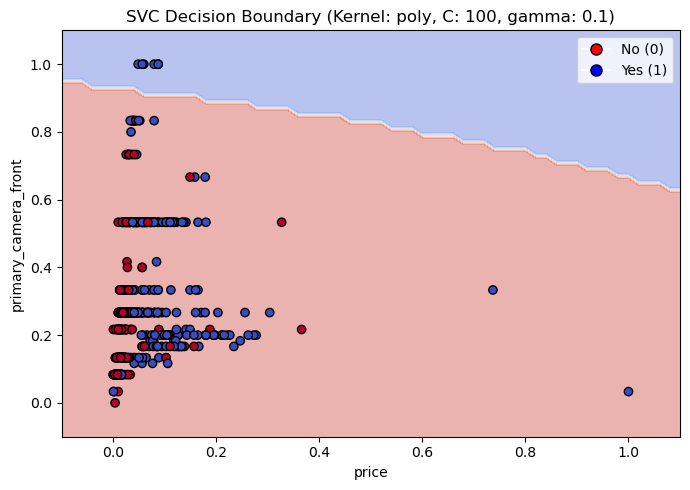

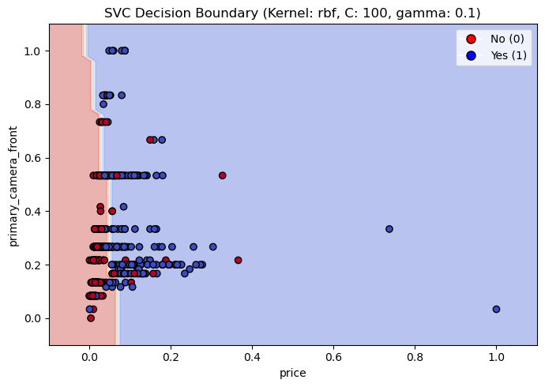

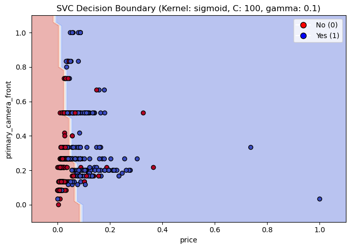

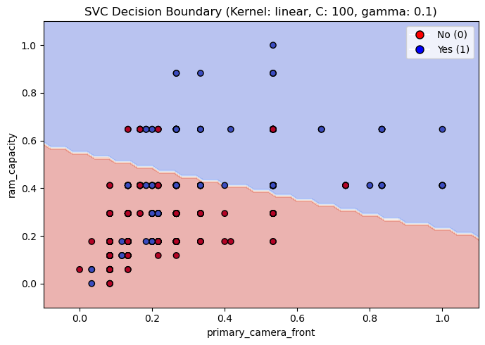

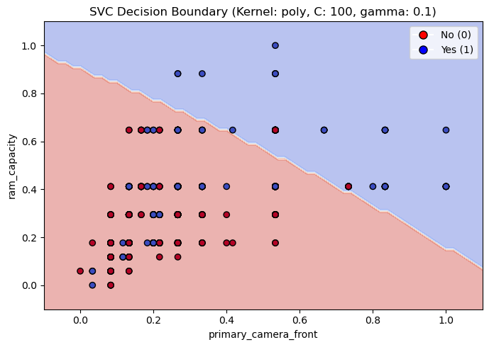

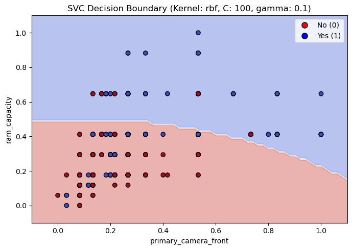

[1 more figures not shown]

```python
import pandas as pd
import numpy as np
import matplotlib.pyplot as plt
import seaborn as sns

from sklearn.model_selection import train_test_split, GridSearchCV
from sklearn.preprocessing import MinMaxScaler, LabelEncoder
from sklearn.svm import SVC
from sklearn.metrics import (
    accuracy_score, precision_score, recall_score,
    f1_score, roc_auc_score, classification_report, confusion_matrix
)
from sklearn.feature_selection import mutual_info_classif


def load_data():
    df = pd.read_csv("ml.csv")
    df["extended_memory_available"] = (df["extended_memory_available"] == "Yes").astype(int)
    df["X5G_or_not"] = (df["X5G_or_not"] == "Yes").astype(int)
    df["fast_charging_available"] = (df["fast_charging_available"] == "Yes").astype(int)

    selected_features = [
        "price", "avg_rating", "X5G_or_not", "processor_speed", "battery_capacity",
        "fast_charging_available", "ram_capacity", "refresh_rate", "primary_camera_front"
    ]

    X = df[selected_features].dropna()
    y = df.loc[X.index, "extended_memory_available"]
    return X, y


def find_most_important_features(X, y, n_pairs=3):
    mi_scores = mutual_info_classif(X, y)
    mi_series = pd.Series(mi_scores, index=range(X.shape[1]))
    top_indices = mi_series.sort_values(ascending=False).index[:5].tolist()
    feature_pairs = []
    for i in range(min(len(top_indices)-1, n_pairs)):
        feature_pairs.append([top_indices[i], top_indices[i+1]])
    return feature_pairs


def plot_decision_boundary(X, y, model, kernel, C, gamma, feature_pair, feature_names):
    X_2d = X[:, feature_pair]
    svc_2d = SVC(kernel=kernel, C=C, gamma=gamma)
    svc_2d.fit(X_2d, y)

    plt.figure(figsize=(7, 5))
    h = 0.02
    x_min, x_max = X_2d[:, 0].min() - 0.1, X_2d[:, 0].max() + 0.1
    y_min, y_max = X_2d[:, 1].min() - 0.1, X_2d[:, 1].max() + 0.1
    xx, yy = np.meshgrid(np.arange(x_min, x_max, h), np.arange(y_min, y_max, h))
    Z = svc_2d.predict(np.c_[xx.ravel(), yy.ravel()])
    Z = Z.reshape(xx.shape)

    plt.contourf(xx, yy, Z, alpha=0.4, cmap=plt.cm.coolwarm)
    scatter = plt.scatter(X_2d[:, 0], X_2d[:, 1], c=y, cmap=plt.cm.coolwarm, edgecolors='k')


    handles = [
        plt.Line2D([0], [0], marker='o', color='w',
                   label='No (0)', markerfacecolor='red', markeredgecolor='k', markersize=8),
        plt.Line2D([0], [0], marker='o', color='w',
                   label='Yes (1)', markerfacecolor='blue', markeredgecolor='k', markersize=8)
    ]
    plt.legend(handles=handles, loc='upper right')

    plt.title(f"SVC Decision Boundary (Kernel: {kernel}, C: {C}, gamma: {gamma})")
    plt.xlabel(feature_names[feature_pair[0]])
    plt.ylabel(feature_names[feature_pair[1]])
    plt.tight_layout()
    plt.show()
def run_final_svm_pipeline():
    X, y = load_data()
    feature_names = X.columns.tolist()

    # Split and scale
    X_train, X_test, y_train, y_test = train_test_split(
        X, y, test_size=0.2, stratify=y, random_state=42
    )
    scaler = MinMaxScaler()
    X_train_scaled = scaler.fit_transform(X_train)
    X_test_scaled = scaler.transform(X_test)

    le = LabelEncoder()
    y_train_encoded = le.fit_transform(y_train)
    y_test_encoded = le.transform(y_test)

    # Hyperparameter tuning
    param_grid = {
        'kernel': ['linear', 'poly', 'rbf', 'sigmoid'],
        'C': [0.1, 1, 10, 100],
        'gamma': [0.01, 0.1, 1]
    }

    grid_search = GridSearchCV(SVC(probability=True), param_grid, cv=5, scoring='accuracy', n_jobs=-1)
    grid_search.fit(X_train_scaled, y_train_encoded)

    best_model = grid_search.best_estimator_
    best_params = grid_search.best_params_

    print("=== BEST PARAMETERS ===")
    print(best_params)

    # Train Set Performance
    y_pred_train = best_model.predict(X_train_scaled)
    train_accuracy = accuracy_score(y_train_encoded, y_pred_train)
    train_f1 = f1_score(y_train_encoded, y_pred_train)

    # Test Set Performance
    y_pred_test = best_model.predict(X_test_scaled)
    test_accuracy = accuracy_score(y_test_encoded, y_pred_test)
    test_f1 = f1_score(y_test_encoded, y_pred_test)
    train_f1 = f1_score(y_train, y_pred_train)
    train_precision = precision_score(y_train, y_pred_train)
    train_recall = recall_score(y_train, y_pred_train)

    print("\n=== TRAINING PERFORMANCE ===")
    print(f"Train Accuracy: {train_acc:.4f}")
    print(f"Train F1 Score: {train_f1:.4f}")
    print(f"Train Precision: {train_precision:.4f}")
    print(f"Train Recall: {train_recall:.4f}")


    print("\n=== TEST PERFORMANCE ===")
    print(f"Test Accuracy: {test_accuracy:.4f}")
    print(f"Test F1 Score: {test_f1:.4f}")

    y_proba = best_model.predict_proba(X_test_scaled)[:, 1]
    print("Test Precision:", precision_score(y_test_encoded, y_pred_test))
    print("Test Recall:", recall_score(y_test_encoded, y_pred_test))
    print("Test ROC AUC:", roc_auc_score(y_test_encoded, y_proba))


    print("\nClassification Report:\n", classification_report(y_test_encoded, y_pred_test))

    # Confusion Matrix
    plt.figure(figsize=(6, 5))
    cm = confusion_matrix(y_test_encoded, y_pred_test)
    sns.heatmap(cm, annot=True, fmt='d', cmap='Blues',
                xticklabels=['No', 'Yes'], yticklabels=['No', 'Yes'])
    plt.title("Confusion Matrix")
    plt.xlabel("Predicted")
    plt.ylabel("Actual")
    plt.tight_layout()
    plt.show()

    # Decision Boundaries
    feature_pairs = find_most_important_features(X_train_scaled, y_train_encoded, n_pairs=3)
    for pair in feature_pairs:
        for kernel in ['linear', 'poly', 'rbf', 'sigmoid']:
            plot_decision_boundary(
                X_train_scaled, y_train_encoded,
                best_model, kernel, best_params['C'], best_params['gamma'],
                pair, feature_names
            )

run_final_svm_pipeline()
```

Support Vector Machine is used for classification by finding optimal hyperplane that separates data points of different classes with maximum margin. In this analysis, first we used hyperparameter tuning approach to decide the best ones:

## Performance Metrics Interpretation

Accuracy: The model correctly classified 85% of the data. Precision: Of all predicted positives (Yes), 83.6% were correct. Recall: Of all actual positives, 95.1% were correctly identified. F1 Score: Harmonic mean of precision and recall—shows strong balance ROC AUC: Excellent model ability to distinguish classes.

## Confusion Matrix Explanation

The model correctly predicts most "Yes" and "No" cases. However, there are 23 false positives and 6 false negatives.

## Decision Boundary Plots Analysis

Each plot visualizes the model's decision surface using a pair of important features. Red and blue areas indicate the regions classified as “No” (0) and “Yes” (1), respectively. Points are also red or blue based on their actual labels.

## Underfit/ overfit

Based on the comparison of model performance on both training and test sets the model shows no signs of overfiting or underfitting. It generalizes well to unseen data.

# ANN

[output not shown]

[output cut: 507 more lines]

[output not shown]

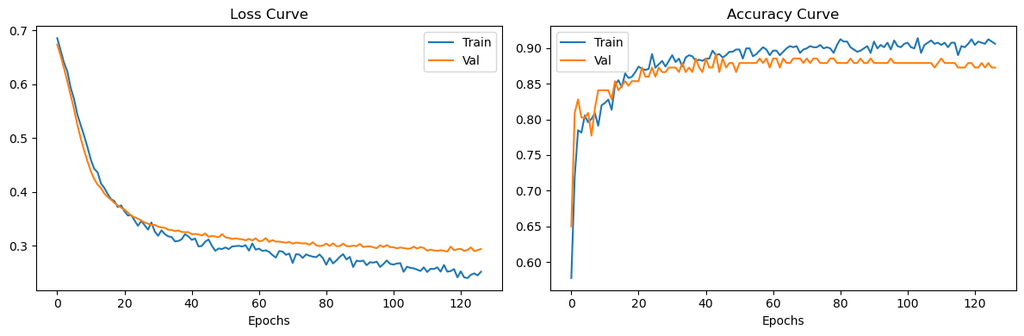

```
25/25 ━━━━━━━━━━━━━━━━━━━━ 0s 773us/step

=== TRAINING PERFORMANCE ===
Train Accuracy: 0.9018
Train F1 Score: 0.9241
Train Precision: 0.9002
Train Recall: 0.9494
7/7 ━━━━━━━━━━━━━━━━━━━━ 0s 1ms/step

=== TEST PERFORMANCE ===
Test Accuracy: 0.8622
Test F1 Score: 0.8966
Test Precision: 0.8540
Test Recall: 0.9435
Test ROC AUC: 0.9092
Model outperforms NIR ✓

Classification Report:
               precision    recall  f1-score   support

           0       0.88      0.72      0.79        72
           1       0.85      0.94      0.90       124

    accuracy                           0.86       196
   macro avg       0.87      0.83      0.85       196
weighted avg       0.86      0.86      0.86       196
```

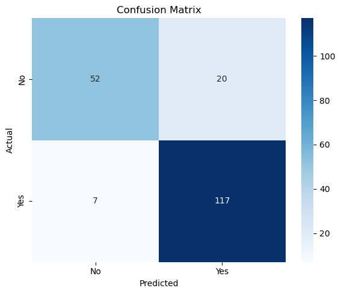

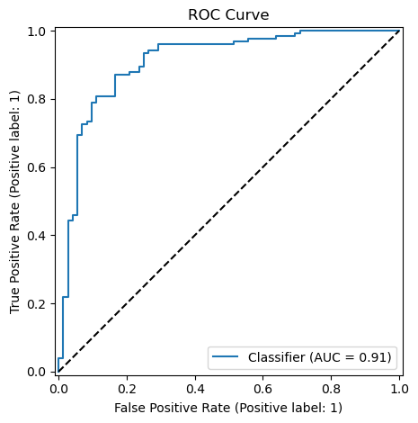

```python
import numpy as np
import pandas as pd
import matplotlib.pyplot as plt
import seaborn as sns
from sklearn.model_selection import train_test_split
from sklearn.preprocessing import MinMaxScaler, LabelEncoder
from sklearn.metrics import (confusion_matrix, accuracy_score, precision_score,
                             recall_score, f1_score, roc_auc_score, classification_report, RocCurveDisplay)
from tensorflow.keras.models import Sequential
from tensorflow.keras.layers import Dense, Dropout
from tensorflow.keras.callbacks import EarlyStopping

np.random.seed(42)

def load_data():
    df = pd.read_csv("ml.csv")
    df["extended_memory_available"] = (df["extended_memory_available"] == "Yes").astype(int)
    df["X5G_or_not"] = (df["X5G_or_not"] == "Yes").astype(int)
    df["fast_charging_available"] = (df["fast_charging_available"] == "Yes").astype(int)

    selected_features = [
        "price", "avg_rating", "X5G_or_not", "processor_speed", "battery_capacity",
        "fast_charging_available", "ram_capacity", "refresh_rate", "primary_camera_front"
    ]

    X = df[selected_features].dropna()
    y = df.loc[X.index, "extended_memory_available"]
    return X, y

def calculate_nir(y_true):
    counts = np.bincount(y_true)
    return np.max(counts) / len(y_true)

def plot_results(y_test, y_pred, y_pred_proba, nir):
    acc = accuracy_score(y_test, y_pred)
    prec = precision_score(y_test, y_pred)
    rec = recall_score(y_test, y_pred)
    f1 = f1_score(y_test, y_pred)
    auc = roc_auc_score(y_test, y_pred_proba)

    print("\n=== TEST PERFORMANCE ===")
    print(f"Test Accuracy: {acc:.4f}")
    print(f"Test F1 Score: {f1:.4f}")
    print(f"Test Precision: {prec:.4f}")
    print(f"Test Recall: {rec:.4f}")
    print(f"Test ROC AUC: {auc:.4f}")
    print("Model outperforms NIR ✓" if acc > nir else "Model does NOT outperform NIR ✗")
    print("\nClassification Report:\n", classification_report(y_test, y_pred))

    plt.figure(figsize=(6, 5))
    cm = confusion_matrix(y_test, y_pred)
    sns.heatmap(cm, annot=True, fmt='d', cmap='Blues', xticklabels=['No', 'Yes'], yticklabels=['No', 'Yes'])
    plt.xlabel('Predicted')
    plt.ylabel('Actual')
    plt.title('Confusion Matrix')
    plt.tight_layout()
    plt.show()

    RocCurveDisplay.from_predictions(y_test, y_pred_proba)
    plt.plot([0, 1], [0, 1], 'k--')
    plt.title("ROC Curve")
    plt.tight_layout()
    plt.show()

def build_model(input_dim, hidden_layers, activation, dropout_rate):
    model = Sequential()
    model.add(Dense(hidden_layers[0], input_dim=input_dim, activation=activation))
    model.add(Dropout(dropout_rate))
    for units in hidden_layers[1:]:
        model.add(Dense(units, activation=activation))
        model.add(Dropout(dropout_rate))
    model.add(Dense(1, activation='sigmoid'))
    model.compile(optimizer='adam', loss='binary_crossentropy', metrics=['accuracy'])
    return model

def main():
    X, y = load_data()
    X_train, X_test, y_train, y_test = train_test_split(X, y, test_size=0.2, stratify=y, random_state=42)
    scaler = MinMaxScaler()
    X_train_scaled = scaler.fit_transform(X_train)
    X_test_scaled = scaler.transform(X_test)

    param_grid = {
        'hidden_layers': [(16,), (32,), (64,), (16, 8), (32, 16), (64, 32)],
        'activation': ['relu', 'tanh', 'elu'],
        'dropout_rate': [0.1, 0.2, 0.3, 0.4],
        'batch_size': [16, 32, 64],
        'epochs': 150
    }

    best_score = 0
    best_params = {}
    best_model = None

    X_train_split, X_val, y_train_split, y_val = train_test_split(
        X_train_scaled, y_train, test_size=0.2, stratify=y_train, random_state=42)

    for hl in param_grid['hidden_layers']:
        for act in param_grid['activation']:
            for dr in param_grid['dropout_rate']:
                for bs in param_grid['batch_size']:
                    model = build_model(X_train.shape[1], hl, act, dr)
                    early_stop = EarlyStopping(monitor='val_loss', patience=10, restore_best_weights=True)
                    model.fit(X_train_split, y_train_split, epochs=param_grid['epochs'], batch_size=bs,
                              validation_data=(X_val, y_val), callbacks=[early_stop], verbose=0)
                    y_val_pred = (model.predict(X_val) > 0.5).astype(int)
                    score = f1_score(y_val, y_val_pred)
                    print(f"{hl}, {act}, dr={dr}, bs={bs} -> F1: {score:.4f}")
                    if score > best_score:
                        best_score = score
                        best_params = {'hidden_layers': hl, 'activation': act, 'dropout': dr, 'batch': bs}
                        best_model = model

    print("\nBest Params:", best_params)
    print("Best F1 Score on Validation:", best_score)

    final_model = build_model(X_train.shape[1], best_params['hidden_layers'], best_params['activation'], best_params['dropout'])
    final_model.fit(X_train_scaled, y_train, epochs=param_grid['epochs'], batch_size=best_params['batch'],
                    validation_split=0.2, callbacks=[EarlyStopping(patience=10, restore_best_weights=True)], verbose=1)

    plt.figure(figsize=(12, 4))
    plt.subplot(1, 2, 1)
    plt.plot(final_model.history.history['loss'], label='Train')
    plt.plot(final_model.history.history['val_loss'], label='Val')
    plt.title('Loss Curve')
    plt.xlabel('Epochs')
    plt.legend()

    plt.subplot(1, 2, 2)
    plt.plot(final_model.history.history['accuracy'], label='Train')
    plt.plot(final_model.history.history['val_accuracy'], label='Val')
    plt.title('Accuracy Curve')
    plt.xlabel('Epochs')
    plt.legend()
    plt.tight_layout()
    plt.show()

    # Training vs Test Performance Comparison
    y_pred_train = (final_model.predict(X_train_scaled).flatten() > 0.5).astype(int)
    train_acc = accuracy_score(y_train, y_pred_train)
    train_f1 = f1_score(y_train, y_pred_train)
    train_precision = precision_score(y_train, y_pred_train)
    train_recall = recall_score(y_train, y_pred_train)

    print("\n=== TRAINING PERFORMANCE ===")
    print(f"Train Accuracy: {train_acc:.4f}")
    print(f"Train F1 Score: {train_f1:.4f}")
    print(f"Train Precision: {train_precision:.4f}")
    print(f"Train Recall: {train_recall:.4f}")


    y_pred_proba = final_model.predict(X_test_scaled).flatten()
    y_pred = (y_pred_proba > 0.5).astype(int)
    nir = calculate_nir(y_test)
    plot_results(y_test, y_pred, y_pred_proba, nir)

if __name__ == '__main__':
    main()
```

## Confusion Matrix

Most mistakes were predicting Yes for actually No, meaning false positives are more common.

## Loss and Accuracy Curves

The left one shows a downward trend, so there is no any overfitting. The right one is shows us model generalizes well.

## Metrics

Accuracy: The model correctly predicts 86% of cases. Precision: When it predicts Yes, it correct 85% of the time. F1 Score: It is 0.89.

The test and training accuracy are really close to each other in terms of accuracy. Just there is a modest drop in F1 score. There is no any underfitting or overfitting problem in our model.

[figure not shown]

It shows 9 input neurons representing features such as price, average rating, and so on. There is 1 hidden layer with 16 neurons and 1 output neuron corresponding to extended_memory_available. Blue connections represent bias values — for example, the bias for the first hidden neuron is 0.70991. The network is fully connected, meaning each neuron in one layer is connected to every neuron in the next. Also, the weights between layers help us understand how each feature influences the network. For instance, the weight from price to the first hidden neuron is −58.979, indicating a strong negative influence. This plot was made by R.

# Random Forest (RF)

```
=== TRAINING PERFORMANCE ===
Train Accuracy: 0.9286
Train F1 Score: 0.9441
Train Precision: 0.9311
Train Recall: 0.9575
Train ROC AUC: 0.9773

=== TEST PERFORMANCE ===
Test Accuracy: 0.8520
Test F1 Score: 0.8854
Test Precision: 0.8682
Test Recall: 0.9032
Test ROC AUC: 0.9021

Best Params: {'max_depth': 5, 'max_features': 'sqrt', 'min_samples_leaf': 1, 'min_samples_split': 3, 'n_estimators': 150}

Classification Report:
               precision    recall  f1-score   support

           0       0.82      0.76      0.79        72
           1       0.87      0.90      0.89       124

    accuracy                           0.85       196
   macro avg       0.84      0.83      0.84       196
weighted avg       0.85      0.85      0.85       196
```

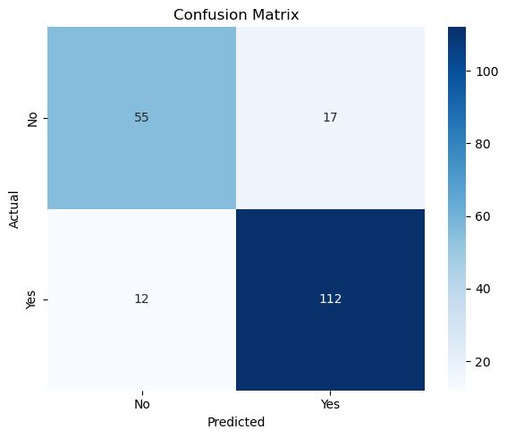

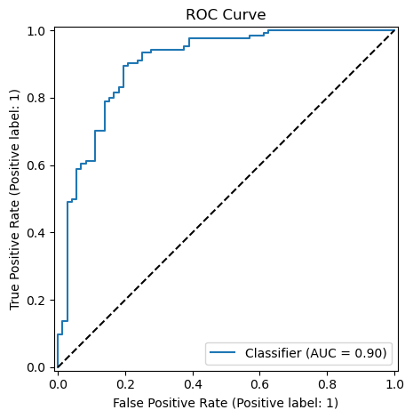

```python
import pandas as pd
import numpy as np
import matplotlib.pyplot as plt
import seaborn as sns
from sklearn.model_selection import train_test_split, GridSearchCV
from sklearn.preprocessing import MinMaxScaler
from sklearn.ensemble import RandomForestClassifier
from sklearn.metrics import (accuracy_score, precision_score, recall_score,
                             f1_score, roc_auc_score, confusion_matrix,
                             classification_report, RocCurveDisplay)
from sklearn.tree import plot_tree

np.random.seed(42)
df = pd.read_csv("ml.csv")
df["extended_memory_available"] = (df["extended_memory_available"] == "Yes").astype(int)
df["X5G_or_not"] = (df["X5G_or_not"] == "Yes").astype(int)
df["fast_charging_available"] = (df["fast_charging_available"] == "Yes").astype(int)

selected_features = [
    "price", "avg_rating", "X5G_or_not", "processor_speed", "battery_capacity",
    "fast_charging_available", "ram_capacity", "refresh_rate", "primary_camera_front"
]

df = df[selected_features + ["extended_memory_available"]].dropna()
X = df[selected_features]
y = df["extended_memory_available"]

X_train, X_test, y_train, y_test = train_test_split(X, y, stratify=y, test_size=0.2, random_state=42)
scaler = MinMaxScaler()
X_train_scaled = scaler.fit_transform(X_train)
X_test_scaled = scaler.transform(X_test)

param_grid = {
    'n_estimators': [50, 100, 150],
    'max_depth': [3, 5, None],
    'min_samples_split': [2, 3, 4],
    'min_samples_leaf': [1, 2, 4],
    'max_features': ['sqrt', 'log2', None]
}

rf = RandomForestClassifier(random_state=42)
grid_search = GridSearchCV(rf, param_grid, cv=5, scoring='f1', n_jobs=-1)
grid_search.fit(X_train_scaled, y_train)
best_model = grid_search.best_estimator_

y_pred = best_model.predict(X_test_scaled)
y_pred_proba = best_model.predict_proba(X_test_scaled)[:, 1]
nir = max(np.bincount(y_test)) / len(y_test)

acc = accuracy_score(y_test, y_pred)
prec = precision_score(y_test, y_pred)
rec = recall_score(y_test, y_pred)
f1 = f1_score(y_test, y_pred)
auc = roc_auc_score(y_test, y_pred_proba)

y_pred_train = best_model.predict(X_train_scaled)
train_acc = accuracy_score(y_train, y_pred_train)
train_f1 = f1_score(y_train, y_pred_train)
train_prec = precision_score(y_train, y_pred_train)
train_rec = recall_score(y_train, y_pred_train)
train_proba = best_model.predict_proba(X_train_scaled)[:, 1]
train_auc = roc_auc_score(y_train, train_proba)

print("\n=== TRAINING PERFORMANCE ===")
print(f"Train Accuracy: {train_acc:.4f}")
print(f"Train F1 Score: {train_f1:.4f}")
print(f"Train Precision: {train_prec:.4f}")
print(f"Train Recall: {train_rec:.4f}")
print(f"Train ROC AUC: {train_auc:.4f}")


print("\n=== TEST PERFORMANCE ===")
print(f"Test Accuracy: {acc:.4f}")
print(f"Test F1 Score: {f1:.4f}")
print(f"Test Precision: {prec:.4f}")
print(f"Test Recall: {rec:.4f}")
print(f"Test ROC AUC: {auc:.4f}")

print("\nBest Params:", grid_search.best_params_)
print("\nClassification Report:\n", classification_report(y_test, y_pred))

plt.figure(figsize=(6, 5))
cm = confusion_matrix(y_test, y_pred)
sns.heatmap(cm, annot=True, fmt='d', cmap='Blues', xticklabels=['No', 'Yes'], yticklabels=['No', 'Yes'])
plt.xlabel('Predicted')
plt.ylabel('Actual')
plt.title('Confusion Matrix')
plt.tight_layout()
plt.show()

RocCurveDisplay.from_predictions(y_test, y_pred_proba)
plt.plot([0, 1], [0, 1], 'k--')
plt.title("ROC Curve")
plt.tight_layout()
plt.show()
```

RF is based on decision trees. It handles non-linear relationships well, is resistant to overfitting, and also it handles mixed data types well. We applied hyperparameter tuning to find best model. n_estimators: Number of tress in the forest. [50, 100, 150] max_depth: Maximum depth of each tree. [3, 5, None], min_samples_split: Minimum number of samples to split an internal node. [2, 3, 4] max_features: Number of features. ['sqrt', 'log2', None] min_samples_leaf: Minimum number of samples required at a leaf node. [1, 2, 4]

The best parameters selected were: {'max_depth': 5, 'max_features': "sqrt", 'min_samples_leaf': 1, 'min_samples_split': 3, 'n_estimators': 150}

## Model Performance

Accuracy: The model correctly predicts 85% of cases. Precision: When it predicts Yes, it correct 87% of the time. Recall: It identifies 90% of actual Yes cases. F1 Score: It is 88%. AUC: It is 90%

## Confusion Matrix

The matrix shows us there are 55 TN, 112 TP, 17 FP and 12 FN values.

## ROC Curve

- Although scaling is not necessary. It was used to create consistency between other ml models.

# XGBoost

```python
import numpy as np
import pandas as pd
import matplotlib.pyplot as plt
import seaborn as sns
import warnings
warnings.filterwarnings('ignore')

from sklearn.datasets import load_breast_cancer
from sklearn.model_selection import train_test_split, cross_val_score
from sklearn.preprocessing import StandardScaler, LabelEncoder
from sklearn.metrics import accuracy_score, precision_score, recall_score, f1_score, classification_report, confusion_matrix


import xgboost as xgb
import lightgbm as lgb
import catboost as cb

# Hyperparameter tuning
import optuna
from optuna.samplers import TPESampler

np.random.seed(42)

class ml_model:
    def __init__(self):
        self.models = {}
        self.best_params = {}
        self.results = {}
        self.scaler = StandardScaler()
        self.label_encoder = LabelEncoder()
    def load_data(self):
        df = pd.read_csv("ml.csv")
        df["extended_memory_available"] = (df["extended_memory_available"] == "Yes").astype(int)
        df["X5G_or_not"] = (df["X5G_or_not"] == "Yes").astype(int)
        df["fast_charging_available"] = (df["fast_charging_available"] == "Yes").astype(int)

        selected_features = [
            "price", "avg_rating", "X5G_or_not", "processor_speed", "battery_capacity",
            "fast_charging_available", "ram_capacity", "refresh_rate", "primary_camera_front"
        ]

        df = df[selected_features + ["extended_memory_available"]].dropna()
        X = df[selected_features]
        y = df["extended_memory_available"]

        return X, y
    def prepare_data(self, X, y, test_size=0.2):
        """Split and scale the data"""
        # Train-test split
        X_train, X_test, y_train, y_test = train_test_split(
            X, y, test_size=test_size, random_state=42, stratify=y
        )

        # Scale features
        X_train_scaled = self.scaler.fit_transform(X_train)
        X_test_scaled = self.scaler.transform(X_test)

        print(f"Training set size: {X_train.shape[0]}")
        print(f"Test set size: {X_test.shape[0]}")

        return X_train_scaled, X_test_scaled, y_train, y_test, X_train.columns

    def xgboost_objective(self, trial, X_train, y_train):
        """Objective function for XGBoost hyperparameter tuning"""
        params = {
            'n_estimators': trial.suggest_int('n_estimators', 100, 1000),
            'max_depth': trial.suggest_int('max_depth', 3, 10),
            'learning_rate': trial.suggest_float('learning_rate', 0.01, 0.3),
            'subsample': trial.suggest_float('subsample', 0.6, 1.0),
            'colsample_bytree': trial.suggest_float('colsample_bytree', 0.6, 1.0),
            'reg_alpha': trial.suggest_float('reg_alpha', 0, 10),
            'reg_lambda': trial.suggest_float('reg_lambda', 0, 10),
            'random_state': 42,
            'eval_metric': 'logloss'
        }

        model = xgb.XGBClassifier(**params)
        scores = cross_val_score(model, X_train, y_train, cv=5, scoring='f1')
        return scores.mean()

    def lightgbm_objective(self, trial, X_train, y_train):
        """Objective function for LightGBM hyperparameter tuning"""
        params = {
            'n_estimators': trial.suggest_int('n_estimators', 100, 1000),
            'max_depth': trial.suggest_int('max_depth', 3, 10),
            'learning_rate': trial.suggest_float('learning_rate', 0.01, 0.3),
            'subsample': trial.suggest_float('subsample', 0.6, 1.0),
            'colsample_bytree': trial.suggest_float('colsample_bytree', 0.6, 1.0),
            'reg_alpha': trial.suggest_float('reg_alpha', 0, 10),
            'reg_lambda': trial.suggest_float('reg_lambda', 0, 10),
            'num_leaves': trial.suggest_int('num_leaves', 10, 300),
            'min_child_samples': trial.suggest_int('min_child_samples', 5, 100),
            'random_state': 42,
            'verbose': -1
        }

        model = lgb.LGBMClassifier(**params)
        scores = cross_val_score(model, X_train, y_train, cv=5, scoring='f1')
        return scores.mean()

    def catboost_objective(self, trial, X_train, y_train):
        """Objective function for CatBoost hyperparameter tuning"""
        params = {
            'iterations': trial.suggest_int('iterations', 100, 1000),
            'depth': trial.suggest_int('depth', 3, 10),
            'learning_rate': trial.suggest_float('learning_rate', 0.01, 0.3),
            'subsample': trial.suggest_float('subsample', 0.6, 1.0),
            'colsample_bylevel': trial.suggest_float('colsample_bylevel', 0.6, 1.0),
            'reg_lambda': trial.suggest_float('reg_lambda', 0, 10),
            'random_state': 42,
            'verbose': False
        }

        model = cb.CatBoostClassifier(**params)
        scores = cross_val_score(model, X_train, y_train, cv=5, scoring='f1')
        return scores.mean()

    def tune_hyperparameters(self, X_train, y_train, n_trials=50):
        """Hyperparameter tuning for all models"""
        print("Starting hyperparameter tuning...")

        # XGBoost tuning
        print("Tuning XGBoost...")
        study_xgb = optuna.create_study(direction='maximize', sampler=TPESampler(seed=42))
        study_xgb.optimize(lambda trial: self.xgboost_objective(trial, X_train, y_train), n_trials=n_trials)
        self.best_params['XGBoost'] = study_xgb.best_params
        print(f"XGBoost best F1: {study_xgb.best_value:.4f}")

        # LightGBM tuning
        print("Tuning LightGBM...")
        study_lgb = optuna.create_study(direction='maximize', sampler=TPESampler(seed=42))
        study_lgb.optimize(lambda trial: self.lightgbm_objective(trial, X_train, y_train), n_trials=n_trials)
        self.best_params['LightGBM'] = study_lgb.best_params
        print(f"LightGBM best F1: {study_lgb.best_value:.4f}")

        # CatBoost tuning
        print("Tuning CatBoost...")
        study_cb = optuna.create_study(direction='maximize', sampler=TPESampler(seed=42))
        study_cb.optimize(lambda trial: self.catboost_objective(trial, X_train, y_train), n_trials=n_trials)
        self.best_params['CatBoost'] = study_cb.best_params
        print(f"CatBoost best F1: {study_cb.best_value:.4f}")
```

```python
        print("Hyperparameter tuning completed!")

    def train_models(self, X_train, y_train):
        """Train all models with best parameters"""
        print("Training models with best parameters...")

        # XGBoost
        self.models['XGBoost'] = xgb.XGBClassifier(**self.best_params['XGBoost'])
        self.models['XGBoost'].fit(X_train, y_train)

        # LightGBM
        self.models['LightGBM'] = lgb.LGBMClassifier(**self.best_params['LightGBM'])
        self.models['LightGBM'].fit(X_train, y_train)

        # CatBoost
        self.models['CatBoost'] = cb.CatBoostClassifier(**self.best_params['CatBoost'])
        self.models['CatBoost'].fit(X_train, y_train)

        print("Model training completed!")

    def evaluate_models(self, X_test, y_test):
        """Evaluate all models and store results"""
        print("Evaluating models on test set...")

        for model_name, model in self.models.items():
            y_pred = model.predict(X_test)

            # Calculate metrics
            accuracy = accuracy_score(y_test, y_pred)
            precision = precision_score(y_test, y_pred)
            recall = recall_score(y_test, y_pred)
            f1 = f1_score(y_test, y_pred)

            self.results[model_name] = {
                'Accuracy': accuracy,
                'Precision': precision,
                'Recall': recall,
                'F1': f1,
                'Predictions': y_pred
            }

            print(f"\n{model_name} Results:")
            print(f"Accuracy: {accuracy:.4f}")
            print(f"Precision: {precision:.4f}")
            print(f"Recall: {recall:.4f}")
            print(f"F1 Score: {f1:.4f}")

    def plot_comparative_analysis(self):
        """Create comparative analysis plots"""
        # Create results DataFrame
        results_df = pd.DataFrame(self.results).T
        results_df = results_df.drop('Predictions', axis=1)

        # Plot comparative metrics
        fig, axes = plt.subplots(2, 2, figsize=(15, 12))

        metrics = ['Accuracy', 'Precision', 'Recall', 'F1']
        colors = ['skyblue', 'lightcoral', 'lightgreen']

        for i, metric in enumerate(metrics):
            ax = axes[i//2, i%2]
            bars = ax.bar(results_df.index, results_df[metric], color=colors)
            ax.set_title(f'{metric} Comparison', fontsize=14, fontweight='bold')
            ax.set_ylabel(metric, fontsize=12)
            ax.set_ylim(0, 1)

            # Add value labels on bars
            for bar in bars:
                height = bar.get_height()
                ax.text(bar.get_x() + bar.get_width()/2., height + 0.01,
                       f'{height:.3f}', ha='center', va='bottom', fontweight='bold')

        plt.tight_layout()
        plt.show()

        # Create a summary table
        print("\n" + "="*60)
        print("COMPARATIVE ANALYSIS SUMMARY")
        print("="*60)
        print(results_df.round(4))

        return results_df

    def plot_confusion_matrices(self, y_test):
        class_names = ['No', 'Yes']

        """Plot confusion matrices for all models"""
        fig, axes = plt.subplots(1, 3, figsize=(18, 5))

        for i, (model_name, model_results) in enumerate(self.results.items()):
            cm = confusion_matrix(y_test, model_results['Predictions'])

            sns.heatmap(cm, annot=True, fmt='d', cmap='Blues',
                       xticklabels=class_names, yticklabels=class_names, ax=axes[i])
            axes[i].set_title(f'{model_name} Confusion Matrix', fontweight='bold')
            axes[i].set_xlabel('Predicted')
            axes[i].set_ylabel('Actual')

        plt.tight_layout()
        plt.show()

    def plot_feature_importance(self, feature_names, top_n=9):
        # Find best model based on F1 score
        best_model_name = max(self.results.keys(), key=lambda x: self.results[x]['F1'])
        best_model = self.models[best_model_name]

        print(f"\nBest performing model based on F1 score: {best_model_name}")
        print(f"F1 Score: {self.results[best_model_name]['F1']:.4f}")

        # Get feature importance
        if hasattr(best_model, 'feature_importances_'):
            importance = best_model.feature_importances_
        else:
            importance = best_model.get_feature_importance()

        # Create feature importance DataFrame
        feat_imp_df = pd.DataFrame({
            'Feature': feature_names,
            'Importance': importance
        }).sort_values('Importance', ascending=False)

        # Plot feature importance
        plt.figure(figsize=(12, 8))
        sns.barplot(x='Importance', y='Feature', data=feat_imp_df.head(top_n), palette='viridis')
        plt.title(f'Feature Importance - {best_model_name}', fontsize=16, fontweight='bold')
        plt.xlabel('Importance', fontsize=12)
        plt.ylabel('Features', fontsize=12)
        plt.tight_layout()
        plt.show()

        # Print top features
        print(f"\nMost important features ({best_model_name}):")
        print("-" * 50)
        for i, row in feat_imp_df.head(top_n).iterrows():
            print(f"{row['Feature']:<30} {row['Importance']:.4f}")

        return best_model_name, feat_imp_df

    def run_complete_analysis(self, n_trials=50):
        """Run the complete analysis pipeline"""
        print("Starting Classification Analysis")
        print("=" * 60)


        X, y = self.load_data()
        X_train, X_test, y_train, y_test, feature_names = self.prepare_data(X, y)

        # Hyperparameter tuning
        self.tune_hyperparameters(X_train, y_train, n_trials=n_trials)

        # Train models
        self.train_models(X_train, y_train)

        # Evaluate models
        self.evaluate_models(X_test, y_test)

        # Create visualizations
        results_df = self.plot_comparative_analysis()
        self.plot_confusion_matrices(y_test)
        best_model_name, feature_importance_df = self.plot_feature_importance(feature_names)

        return results_df, best_model_name, feature_importance_df


if __name__ == "__main__":
    # Create classifier instance
    classifier = ml_model()
```

```
[I 2025-06-20 13:59:40,321] A new study created in memory with name: no-name-ce9c56ae-619d-4d4f-9732-85192a178e1d
```

```
Starting Classification Analysis
============================================================
Training set size: 784
Test set size: 196
Starting hyperparameter tuning...
Tuning XGBoost...
```

[output not shown]

[output cut: 19 more lines]

```
XGBoost best F1: 0.9238
Tuning LightGBM...
```

[output not shown]

[output cut: 10 more lines]

```
LightGBM best F1: 0.9271
Tuning CatBoost...
```

[output not shown]

[output cut: 17 more lines]

[output not shown]

[output cut: 98 more lines]

```
Precision: 0.8779
Recall: 0.9274
F1 Score: 0.9020

LightGBM Results:
Accuracy: 0.8622
Precision: 0.8819
Recall: 0.9032
F1 Score: 0.8924

CatBoost Results:
Accuracy: 0.8520
Precision: 0.8626
Recall: 0.9113
F1 Score: 0.8863
```

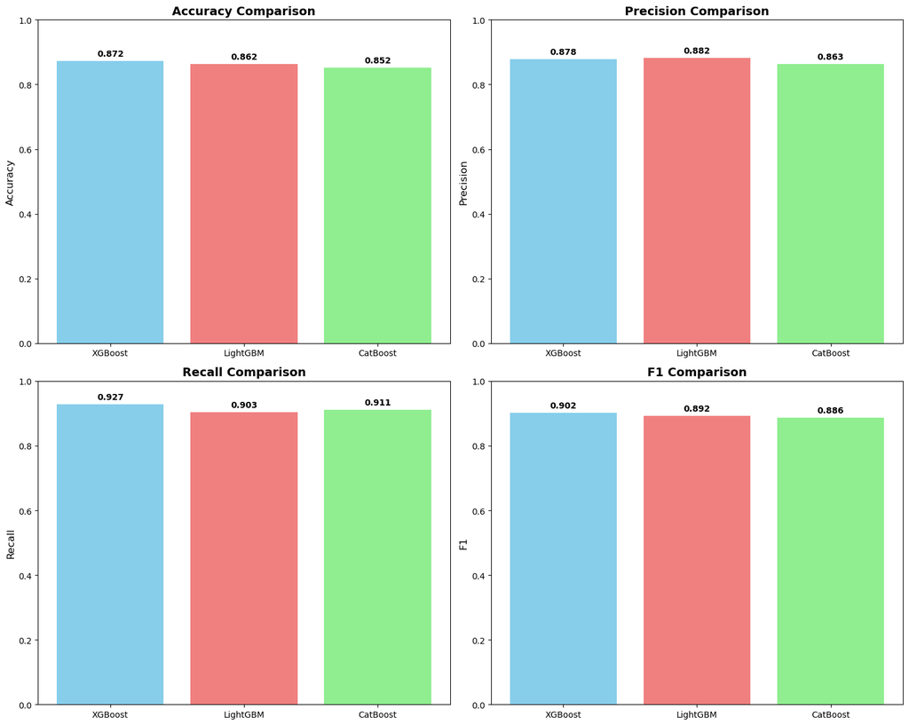

```
============================================================
COMPARATIVE ANALYSIS SUMMARY
============================================================
          Accuracy Precision    Recall        F1
XGBoost   0.872449  0.877863  0.927419  0.901961
LightGBM  0.862245   0.88189  0.903226   0.89243
CatBoost  0.852041  0.862595   0.91129  0.886275
```

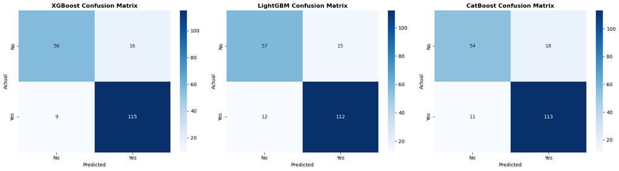

```
Best performing model based on F1 score: XGBoost
F1 Score: 0.9020
```

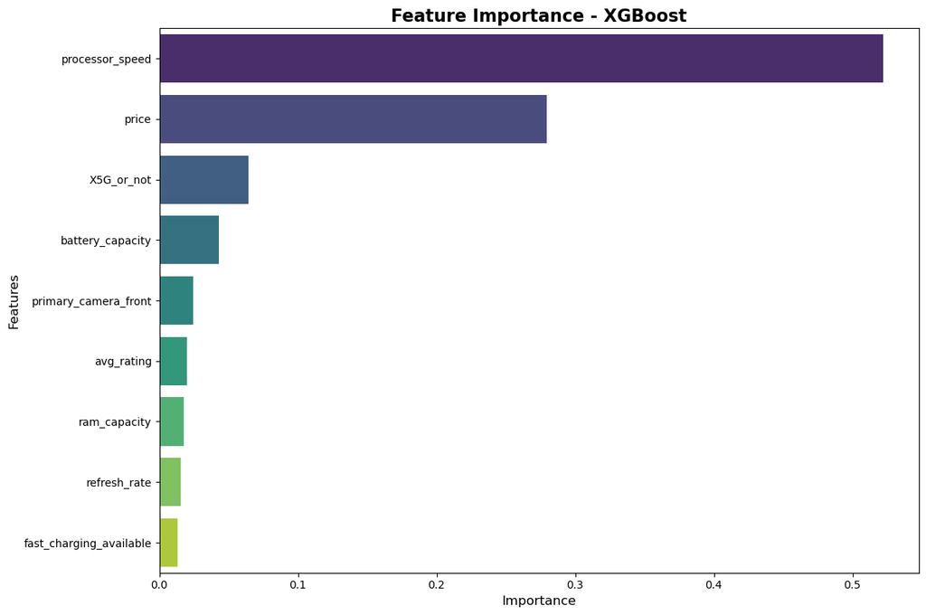

```
Most important features (XGBoost):
--------------------------------------------------
processor_speed                0.5219
price                          0.2796
X5G_or_not                     0.0641
battery_capacity               0.0431
primary_camera_front           0.0246
avg_rating                     0.0199
ram_capacity                   0.0179
refresh_rate                   0.0154
fast_charging_available        0.0134

============================================================
ANALYSIS COMPLETED SUCCESSFULLY!
============================================================
Best performing model: XGBoost
Best F1 Score: 0.9020
```

```python
    results_df, best_model, feature_importance = classifier.run_complete_analysis(n_trials=30)

    print("\n" + "="*60)
    print("ANALYSIS COMPLETED SUCCESSFULLY!")
    print("="*60)
    print(f"Best performing model: {best_model}")
    print(f"Best F1 Score: {results_df.loc[best_model, 'F1']:.4f}")
```

## Confusion Matrix Analysis for XGBoost:

It is balanced, it gives the best F1 score.

## Feature Importance Plot:

Processor speed is the most important feature. Fast charging available, RAM capacity and primary camera front are less important.

```python
import numpy as np
import pandas as pd
import matplotlib.pyplot as plt
import seaborn as sns
import optuna
from optuna.samplers import TPESampler
from sklearn.model_selection import train_test_split, cross_val_score
from sklearn.preprocessing import StandardScaler
from sklearn.metrics import (accuracy_score, precision_score, recall_score,
                             f1_score, confusion_matrix)
import xgboost as xgb
import lightgbm as lgb
import catboost as cb


np.random.seed(42)

df = pd.read_csv("ml.csv")
df["extended_memory_available"] = (df["extended_memory_available"] == "Yes").astype(int)
df["X5G_or_not"] = (df["X5G_or_not"] == "Yes").astype(int)
df["fast_charging_available"] = (df["fast_charging_available"] == "Yes").astype(int)

selected_features = [
    "price", "avg_rating", "X5G_or_not", "processor_speed", "battery_capacity",
    "fast_charging_available", "ram_capacity", "refresh_rate", "primary_camera_front"
]

X = df[selected_features].dropna()
y = df.loc[X.index, "extended_memory_available"]

X_train, X_test, y_train, y_test = train_test_split(
    X, y, test_size=0.2, random_state=42, stratify=y
)

scaler = StandardScaler()
X_train_scaled = scaler.fit_transform(X_train)
X_test_scaled = scaler.transform(X_test)

def xgboost_objective(trial):
    params = {
        'n_estimators': trial.suggest_int('n_estimators', 100, 1000),
        'max_depth': trial.suggest_int('max_depth', 3, 10),
        'learning_rate': trial.suggest_float('learning_rate', 0.01, 0.3),
        'subsample': trial.suggest_float('subsample', 0.6, 1.0),
        'colsample_bytree': trial.suggest_float('colsample_bytree', 0.6, 1.0),
        'reg_alpha': trial.suggest_float('reg_alpha', 0, 10),
        'reg_lambda': trial.suggest_float('reg_lambda', 0, 10),
        'random_state': 42,
        'eval_metric': 'logloss',
        'use_label_encoder': False
    }
    model = xgb.XGBClassifier(**params)
    scores = cross_val_score(model, X_train_scaled, y_train, cv=5, scoring='f1')
    return scores.mean()

study_xgb = optuna.create_study(direction='maximize', sampler=TPESampler(seed=42))
study_xgb.optimize(xgboost_objective, n_trials=30)

best_params = study_xgb.best_params
print("\n=== Best XGBoost Parameters Found ===")
print(best_params)

xgb_model = xgb.XGBClassifier(**best_params)
xgb_model.fit(X_train_scaled, y_train)

y_pred_test = xgb_model.predict(X_test_scaled)
y_pred_train = xgb_model.predict(X_train_scaled)

acc_test = accuracy_score(y_test, y_pred_test)
prec_test = precision_score(y_test, y_pred_test)
rec_test = recall_score(y_test, y_pred_test)
f1_test = f1_score(y_test, y_pred_test)

acc_train = accuracy_score(y_train, y_pred_train)
prec_train = precision_score(y_train, y_pred_train)
rec_train = recall_score(y_train, y_pred_train)
f1_train = f1_score(y_train, y_pred_train)

print("\n=== XGBoost Evaluation - Train ===")
print(f"Accuracy: {acc_train:.4f}")
print(f"Precision: {prec_train:.4f}")
print(f"Recall: {rec_train:.4f}")
print(f"F1 Score: {f1_train:.4f}")

print("\n=== XGBoost Evaluation - Test ===")
print(f"Accuracy: {acc_test:.4f}")
print(f"Precision: {prec_test:.4f}")
print(f"Recall: {rec_test:.4f}")
print(f"F1 Score: {f1_test:.4f}")
```

[output not shown]

[output cut: 11 more lines]

```
=== Best XGBoost Parameters Found ===
{'n_estimators': 640, 'max_depth': 6, 'learning_rate': 0.19524510190909045, 'subsample': 0.7516997660881289, 'colsample_bytree': 0.9989102003984727, 'reg_alpha': 6.394160822203044, 'reg_lambda': 3.7397770574158447}

=== XGBoost Evaluation - Train ===
Accuracy: 0.9401
Precision: 0.9426
Recall: 0.9636
F1 Score: 0.9530

=== XGBoost Evaluation - Test ===
Accuracy: 0.8724
Precision: 0.8779
Recall: 0.9274
F1 Score: 0.9020
```